# S35 Accelerator & Detector Physics

## Accelerator Physics by Professor Adrian Oeftiger

[figure not shown]

### Lecture 6: Off-momentum Effects, Synchrotron Radiation

## Run this notebook online!

Interact and run this jupyter notebook online:

via the local Physics Jupyterlab service:

via the public mybinder.org service:

Also find this lecture rendered [as HTML slides on github $\nearrow$](https://aoeftiger.github.io/UOXF-AP-2026/) along with the [source repository $\nearrow$](https://github.com/aoeftiger/UOXF-AP-2026).

## Run this first!

Imports and modules:

```python
from config import (np, plt, sys, Madx, interp1d, PyNAFF,
                    pysixtrack, elements,
                    M_drift, M_dip_x, M_dip_y,
                    M_quad_x, M_quad_y,
                    track, track_sext_4D)
%matplotlib inline
```

## Refresher!

1. Hill Differential Equation & Floquet Theory
2. Twiss Parametrisation and Optics
3. The FODO Cell

## Today!

1. Off-momentum Particles: Dispersion & Chromaticity
2. Synchrotron Radiation

## Part I: Off-momentum Particles, Dispersion & Chromaticity

## Off-momentum Trajectory

[figure not shown]

Particles with a momentum $p\neq p_0$ different from reference momentum $p_0$ are bent by magnetic fields $B$ on a different bending radius $\rho$:

$$B\rho=\cfrac{p}{|q|}$$

In particular, higher-momentum particles are bent less, and their off-momentum trajectory encompasses two major effects:

1. Dispersion (dipole magnets, change of closed orbit)
2. Chromaticity (quadrupole magnets, change of focusing)

image by [Y. Hao](https://people.nscl.msu.edu/~haoy/teaching/fundamental_AP/transverse_dynamics/transverse_dynamics.html)

## Dispersion

[figure not shown]

Since dipole magnets define the reference orbit (cf. Frenet-Serret coordinate system), off-momentum particles will experience a different "dispersive" closed orbit – dipoles are said to "generate" dispersion.

The dispersion function $D(s)$ describes the local equilibrium offset from the reference closed orbit due to a momentum deviation $\delta=\Delta p/p_0$ with respect to the synchronous reference particle:

$$x(s)=\underbrace{x_\beta}\limits_{\mathop{=}\sqrt{2J_x\beta_x(s)}\cos(\psi_x(s))} + x_\text{disp}\qquad\text{with}\qquad x_\text{disp}(s) = D_x(s) \cdot \delta$$

$D_x(s)$ hence represents the (horizontal) closed orbit for a particle with $\delta=1$, i.e. twice the reference momentum.

image by [A. Lasheen / JUAS](https://e-publishing.cern.ch/index.php/CYRSP/article/view/1586/1315)

### Simulation 1: Computing the Dispersion Function of a FODO cell

For illustration, we use again the LHC FODO cell:

```python
madx = Madx(stdout=sys.stdout)

madx.input('''
k1l_f := 0.008 * 3.3;  // inverse focal length qf
k1l_d := -0.008 * 3.3; // inverse focal length qd
theta := 0;            // in LHC: 2 * pi / 1232;

qf2: quadrupole, l = 3.3 / 2, k1 := k1l_f / 3.3; // half a focusing quad
qd:  quadrupole, l = 3.3,     k1 := k1l_d / 3.3;
dip: sbend, l = 14.3, angle := theta;

fodo: sequence, l = 110;
qf2, at = 3.3 / 4;
dip, at = 12;
dip, at = 2 * 110 / 8;
dip, at = 110 / 2 - 12;
qd, at = 110 / 2;
dip, at = 110 / 2 + 12;
dip, at = 6 * 110 / 8;
dip, at = 110 - 12;
qf2, at = 110 - 3.3 / 4;
endsequence;
''');

madx.command.beam(particle='proton', energy=7e3) # energy is in GeV!
madx.use(sequence='fodo')

# output the Twiss parameters every 1m
madx.command.select(flag="interpolate", sequence="fodo", step=1);

twiss = madx.twiss();
qx_fodo = twiss.summary['q1']
qpx_fodo = twiss.summary['dq1'] # multiplied by beta~1
```

```
  ++++++++++++++++++++++++++++++++++++++++++++
  +     MAD-X 5.09.03  (64 bit, Darwin)      +
  + Support: mad@cern.ch, http://cern.ch/mad +
  + Release   date: 2024.04.25               +
  + Execution date: 2026.05.08 11:22:59      +
  ++++++++++++++++++++++++++++++++++++++++++++
enter Twiss module

iteration:   1 error:   0.000000E+00 deltap:   0.000000E+00
orbit:   0.000000E+00  0.000000E+00  0.000000E+00  0.000000E+00  0.000000E+00  0.000000E+00

++++++ table: summ

            length             orbit5               alfa            gammatr
               110                 -0                  0                  0

                q1                dq1            betxmax              dxmax
      0.2518947018      -0.3220961047        186.9084848                  0

             dxrms             xcomax             xcorms                 q2
                 0                  0                  0       0.2518947018

               dq2            betymax              dymax              dyrms
     -0.3220961047        186.4581481                  0                  0

            ycomax             ycorms             deltap            synch_1
                 0                  0                  0                  0

           synch_2            synch_3            synch_4            synch_5
                 0                  0                  0                  0

           synch_6            synch_8             nflips              dqmin
                 0                  0                  0                  0

       dqmin_phase
                 0
```

```python
madx.input('value, beam->beta;')
```

```
beam->beta         =        0.999999991 ;
```

```
True
```

We "switch" on the dipole magnets by defining a non-zero bending angle:

```python
madx.input('theta := 2 * pi / 1232;');
```

```
++++++ info: theta redefined
```

Let us recompute the optics functions, as this time also the dispersion function will assume finite values ($\leadsto$ why?):

```python
twiss = madx.twiss();
```

```
enter Twiss module

iteration:   1 error:   0.000000E+00 deltap:   0.000000E+00
orbit:   0.000000E+00  0.000000E+00  0.000000E+00  0.000000E+00  0.000000E+00  0.000000E+00

++++++ table: summ

            length             orbit5               alfa            gammatr
               110                 -0    0.0004388874913        47.73351305

                q1                dq1            betxmax              dxmax
      0.2519723158      -0.3218296078        186.8781443        2.249453549

             dxrms             xcomax             xcorms                 q2
       1.634089545                  0                  0       0.2518947018

               dq2            betymax              dymax              dyrms
     -0.3218849941        186.4581481                  0                  0

            ycomax             ycorms             deltap            synch_1
                 0                  0                  0                  0

           synch_2            synch_3            synch_4            synch_5
                 0                  0                  0                  0

           synch_6            synch_8             nflips              dqmin
                 0                  0                  0                  0

       dqmin_phase
                 0
```

Given that $D=\cfrac{x}{\delta}$ for the equilibrium orbit at a momentum deviation $\delta$, the dispersion function $D(s)$ satisfies the inhomogeneous Hill differential equation

$$D'' + \left(\frac{1}{\rho_0(s)} + k(s)\right)\cdot D = \frac{1}{\rho_0(s)}$$

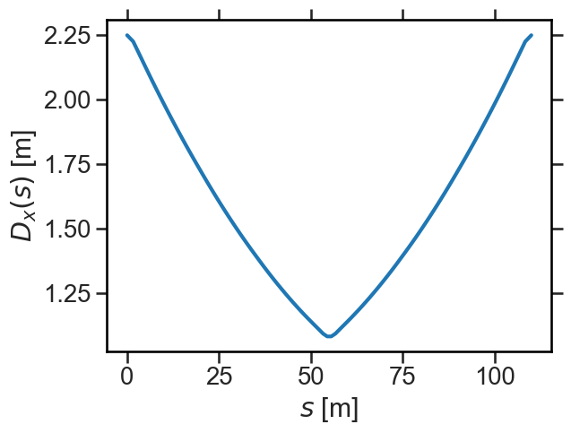

```python
plt.plot(twiss['s'], twiss['dx'] * 0.999999991) # multiplied by beta~1
plt.xlabel('$s$ [m]')
plt.ylabel('$D_x(s)$ [m]');
```

$\implies$ Dispersion function $D(s)$ is focused by the quadrupoles, analogous to the horizontal $\beta_x(s)$-function!

$\leadsto$ Verify that the dispersion is generated by the dipole magnets! (What does this mean?) How does the dispersion function $D(s)$ look like when the dipole fields are switched off?

### Simulation 2: Dispersion Effect in Tracking

To illustrate the dispersion effect, we use the thin-lens tracking code `PySixTrack` (like our thin-lens betatron matrices but for 6D, i.e. including the momentum deviation $\delta$)!

We define a drift of $5\,$m length and a dipole with a bending angle of $0.1\,$rad:

```python
drift = elements.DriftExact(5)
dipole = elements.Multipole(knl=[0.1], hxl=0.1)
```

```python
part0 = pysixtrack.Particles(x=0, delta=0)
part1 = pysixtrack.Particles(x=0, delta=0.001)
```

Track through the drift, then the dipole and again the drift:

```python
rec_x0 = [part0.x]
rec_x1 = [part1.x]

drift.track(part0)
drift.track(part1)

rec_x0 += [part0.x]
rec_x1 += [part1.x]

dipole.track(part0)
dipole.track(part1)

rec_x0 += [part0.x]
rec_x1 += [part1.x]

drift.track(part0)
drift.track(part1)

rec_x0 += [part0.x]
rec_x1 += [part1.x]
```

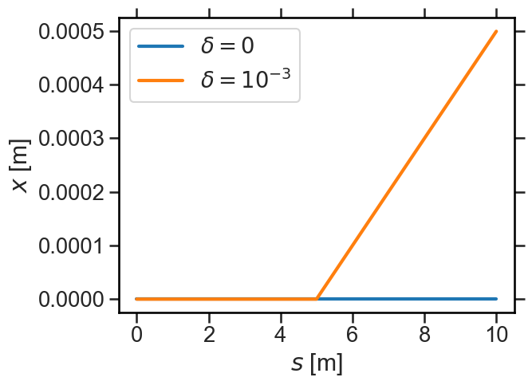

```python
plt.plot([0, 5, 5, 10], rec_x0, label='$\delta=0$')
plt.plot([0, 5, 5, 10], rec_x1, label='$\delta=10^{-3}$')

plt.xlabel('$s$ [m]')
plt.ylabel('$x$ [m]')
plt.legend();
```

$\leadsto$ Please explain what happens here and why.

## Chromaticity

Chromaticity describes the change of focusing for off-momentum particles at $p=p_0(1+\delta)$.  
The chromatic aberration of a quadrupole focusing lens with gradient $\frac{\partial B_y}{\partial x}$ yields:

$$k \equiv \cfrac{1}{B\rho}\cfrac{\partial B_y}{\partial x} \propto \cfrac{1}{p}\implies k(\delta)=\cfrac{k}{1+\delta}$$

Therefore, quadrupoles focus less for higher-momentum particles $\delta>0$ and thus the tune $Q$ decreases. The chromaticity of an accelerator is defined as

$$Q'=\frac{dQ}{d\delta}$$

The natural chromaticity of a (linear) magnetic lattice is typically negative.

### Simulation 3: Chromaticity Effect in Tracking

Let us illustrate by tracking particles in `PySixTrack` again. We define a quadrupole with an integrated focusing strength of $k\cdot L=0.3\,$m${}^{-1}$:

```python
quad = elements.Multipole(knl=[0, 0.3])
```

$\leadsto$ What is the expected focal length $f=\cfrac{1}{k\cdot L}$?

Initialise two sets of particles with the same distribution in $x$, one of which features a momentum deviation of $\delta=0.1$ (!):

$\leadsto$ What is the expected focal length change $\Delta f(\delta)$ for these $\delta=0.1$ particles?

```python
npart = 11
x_dist = np.linspace(-0.05, 0.05, npart)
```

```python
part0 = pysixtrack.Particles(x=x_dist.copy(), delta=0)
part1 = pysixtrack.Particles(x=x_dist.copy(), delta=0.1)
```

Track through the $5\,$m drift, then through the quadrupole and again through the same drift:

```python
rec_x0 = [part0.x.copy()]
rec_x1 = [part1.x.copy()]

drift.track(part0)
drift.track(part1)

rec_x0 += [part0.x.copy()]
rec_x1 += [part1.x.copy()]

quad.track(part0)
quad.track(part1)

rec_x0 += [part0.x.copy()]
rec_x1 += [part1.x.copy()]

drift.track(part0)
drift.track(part1)

rec_x0 += [part0.x.copy()]
rec_x1 += [part1.x.copy()]
```

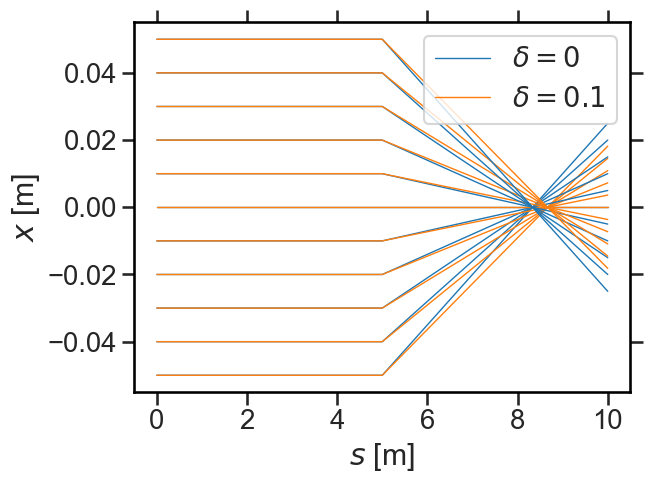

```python
for i in range(npart):
    l0, = plt.plot([0, 5, 5, 10], np.array(rec_x0)[:, i], c='C0', lw=1)
    l1, = plt.plot([0, 5, 5, 10], np.array(rec_x1)[:, i], c='C1', lw=1)

plt.xlabel('$s$ [m]')
plt.ylabel('$x$ [m]')
plt.legend([l0, l1], ['$\delta=0$', '$\delta=0.1$']);
```

$\implies$ We observe less focusing for $\delta>0$ particles $\implies$ less phase advance in quasi-harmonic oscillation $\implies$ negative tune shift!

## Natural Chromaticity of a FODO Cell

Natural chromaticity of a FODO cell with phase advance $\Phi_\text{FODO}$ can be derived via *thin-lens approximation* ([lecture 4](https://aoeftiger.github.io/UOXF-AP-2026/lecture4/lecture.slides.html#/27)):

$$Q'_\text{FODO} = -\frac{1}{\pi}\tan\left(\frac{\Phi_\text{FODO}}{2}\right)$$

Natural chromaticity is always negative ($\leadsto$ why?).

### Simulation 4: Chromatic Detuning in a FODO Cell from Tracking

Let us track with `PySixTrack` through the LHC FODO cell for a distribution of particles with momentum spread and observe the chromatic tune shift.

We first define the same FODO cell as in `MAD-X` before (just in thin-lens approximation and without dipoles):

```python
kL = 0.008 * 3.3

qf2_fodo = elements.Multipole(knl=[0, kL / 2.])
qd_fodo = elements.Multipole(knl=[0, -kL])
drift_fodo = elements.DriftExact(110 / 2.)

fodo = [qf2_fodo, drift_fodo, qd_fodo, drift_fodo, qf2_fodo]
```

We initialise a distribution of `npart` macro-particles, with a momentum spread between $\delta\in[-10^{-3},10^{-3}]$ at a fixed initial horizontal position of $x=0.04\,$m:

```python
npart = 21
x_ini = 0.04
delta = np.linspace(-0.001, 0.001, npart)

particles = pysixtrack.Particles(x=x_ini, delta=delta)
```

We will record the $x$ position after each FODO cell for each particle:

```python
ncells = 1024

rec_x = np.zeros((ncells, npart), dtype=float)
rec_x[0] = particles.x
```

Let's go for the tracking:

```python
for i in range(1, ncells):
    for el in fodo:
        el.track(particles)
    rec_x[i] = particles.x
```

Comparing two particles with same initial $x$ but different $\delta$, we already see the different phase advance in the recorded horizontal motion:

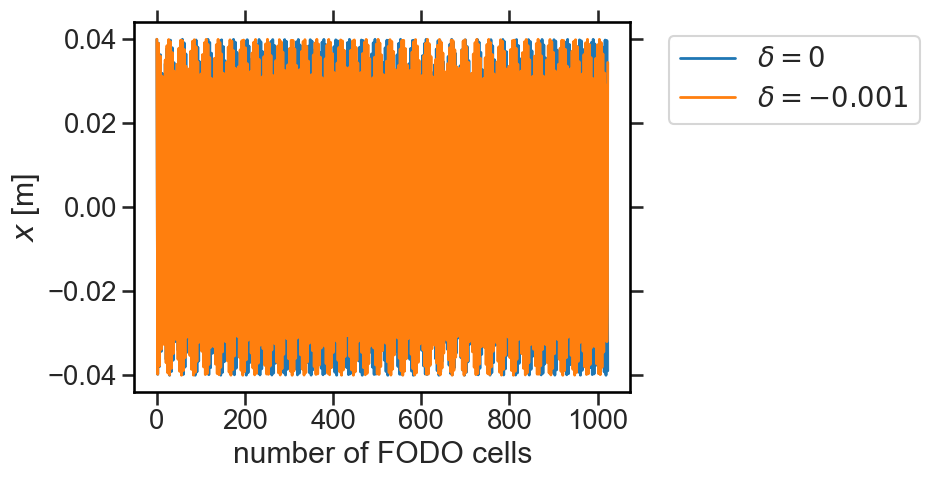

```python
plt.plot(rec_x[:, npart//2 + 1], lw=2, label='$\delta=0$')
plt.plot(rec_x[:, 0], lw=2, label='$\delta=-0.001$')

plt.xlabel('number of FODO cells')
plt.ylabel('$x$ [m]')
plt.legend(bbox_to_anchor=(1.05, 1));
```

Let's evaluate the tune of each particle using the NAFF algorithm:

```python
Qx_delta = np.zeros(npart, dtype=float)

for i in range(npart):
    Qx_delta[i] = PyNAFF.naff(rec_x[:, i], turns=ncells, nterms=1)[0, 1]
```

The tune of the $\delta=0$ particle should be the tune of the reference particle in this linear lattice:

```python
Qx_delta[npart//2 + 1]
```

```
np.float64(0.2585892190147644)
```

```python
qx_fodo
```

```
0.2518947018
```

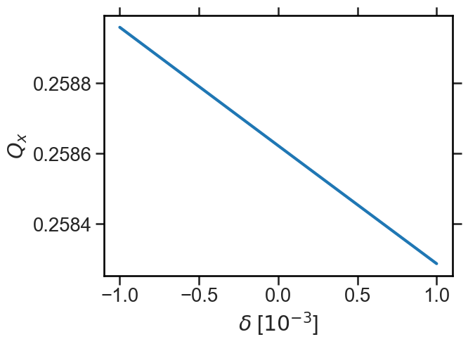

```python
plt.plot(1e3 * delta, Qx_delta)

plt.xlabel('$\delta$ [$10^{-3}$]')
plt.ylabel('$Q_x$');
```

$\implies$ The tune changes with the momentum, as anticipated! The slope of this line is the first-order chromaticity $Q'_x$!

The `numpy` function `polyfit` is useful for a quick linear regression, the output is $(a,b)$ for $y=a\cdot x + b$:

```python
np.polyfit(delta, Qx_delta, 1)
```

```
array([-0.3360318 ,  0.25862306])
```

The slope and thus the chromaticity of the LHC FODO cell is approximately $Q'_x=-0.3$, measured via particle tracking.

#### Comparison

The analytic formula $Q'_\text{FODO} = -\frac{1}{\pi}\tan\left(\frac{\Phi_\text{FODO}}{2}\right)$ gives:

```python
-1 / np.pi * np.tan(2 * np.pi * qx_fodo / 2)
```

```
np.float64(-0.32212202611662033)
```

`MAD-X` would have given us this value, too, we evaluated it as `twiss.summary['dq1'] * beta` (where `beta` is the speed of the particles):

```python
qpx_fodo
```

```
-0.3220961047
```

## Bonus: Chromaticity Correction with Sextupoles

On average over many turns (during which $\delta$ remains more or less constant – remember synchrotron motion is much slower than tranverse betatron motion), the horizontal position of the particles corresponds to their dispersive closed orbit:

$$\langle x \rangle = \langle x_\beta + x_\text{disp}\rangle = \langle \sqrt{2J\beta_x}\underbrace{\cos(\psi_x+\psi_{x0}) }\limits_{\langle\cos\rangle\mathop{=}0}\rangle + \langle D\cdot \delta\rangle = D\cdot \delta$$

Sextupole magnets provide a means to correct for chromaticity in a location where $D(s)\neq 0$ such that particles are on average sorted by momentum $\delta$.

### Bonus Simulation 5: Chromaticity Correction in a FODO Cell

For demonstration, we add sextupoles to the FODO lattice in `MAD-X` and compute their necessary strength.

Make sure that dipoles are switched on, the dipole angle `theta` should be non-zero:

```python
madx.input('value, theta;')
```

```
theta              =     0.005099988074 ;
```

```
True
```

(Otherwise re-run the notebook in order, you need the line `madx.input('theta := 2 * pi / 1232;')`)

We add two sextupole magnets, one next to each quadrupole:

```python
madx.input('sext1: sextupole, l = 1, k2 := k2sext1;')
madx.input('sext2: sextupole, l = 1, k2 := k2sext2;')
madx.command.seqedit(sequence='fodo')
madx.command.install(element='sext1', at=3.3/2 + 1)
madx.command.install(element='sext2', at=110/2 + 3.3/2 + 1)
madx.command.endedit()
```

```
++++++ info: seqedit - number of elements installed:  2
++++++ info: seqedit - number of elements moved:      0
++++++ info: seqedit - number of elements removed:    0
++++++ info: seqedit - number of elements replaced:   0
```

```
True
```

```python
madx.use('fodo')
```

```python
madx.input(
'''match, sequence = fodo;
global, sequence = fodo, dq1 = {Qpx}, dq2 = {Qpy};
vary, name = k2sext1, step = 0.0001;
vary, name = k2sext2, step = 0.0001;
lmdif, tolerance = 1e-12;
endmatch;
'''.format(Qpx=0, Qpy=0))
```

```
START MATCHING

number of sequences: 1
sequence name: fodo
number of variables:    2
user given constraints: 2
total constraints:      2

START LMDIF:

Initial Penalty Function =   0.20718425E+00


call:       4   Penalty function =   0.11711009E-26
 ++++++++++ LMDIF ended: converged successfully
call:       4   Penalty function =   0.11711009E-26

MATCH SUMMARY

Node_Name                  Constraint   Type  Target Value       Final Value        Penalty
--------------------------------------------------------------------------------------------------
Global constraint:         dq1          4     0.00000000E+00     2.20777692E-14     4.87427893E-28
Global constraint:         dq2          4     0.00000000E+00    -2.61471410E-14     6.83672981E-28


Final Penalty Function =   1.17110087e-27





Variable                 Final Value  Initial Value Lower Limit  Upper Limit
--------------------------------------------------------------------------------
k2sext1                   1.27667e-02  0.00000e+00 -1.00000e+20  1.00000e+20
k2sext2                  -2.53671e-02  0.00000e+00 -1.00000e+20  1.00000e+20

END MATCH SUMMARY

VARIABLE "TAR" SET TO   1.17110087e-27
```

```
True
```

$\implies$ The iterative algorithm in `MAD-X` has found suitable values of the sextupole strengths `k2sext1` and `k2sext2` such that the target chromaticity has been corrected to 0.

```python
twiss = madx.twiss();

twiss.summary.dq1 # this is the chromaticity
```

```
enter Twiss module

iteration:   1 error:   0.000000E+00 deltap:   0.000000E+00
orbit:   0.000000E+00  0.000000E+00  0.000000E+00  0.000000E+00  0.000000E+00  0.000000E+00

++++++ table: summ

            length             orbit5               alfa            gammatr
               110                 -0    0.0004388874913        47.73351305

                q1                dq1            betxmax              dxmax
      0.2519723158     2.20777692e-14        186.8781443        2.249453549

             dxrms             xcomax             xcorms                 q2
       1.634424445                  0                  0       0.2518947018

               dq2            betymax              dymax              dyrms
  -2.614714098e-14        186.4581481                  0                  0

            ycomax             ycorms             deltap            synch_1
                 0                  0                  0                  0

           synch_2            synch_3            synch_4            synch_5
                 0                  0                  0                  0

           synch_6            synch_8             nflips              dqmin
                 0                  0                  0                  0

       dqmin_phase
                 0
```

```
2.20777692e-14
```

$\implies$ The chromaticity from the `MAD-X` optics computation has really become (numerically) zero!

We return to the `PySixTrack` tracking: after adding sextupoles of these strengths and the dipole magnets, we should be able to see the change via evaluating the chromaticity via NAFF from tracking data again!

As a short cut, we make the `MAD-X` lattice "thin" (apply thin-lens approximation) and transfer the lattice with dipoles and sextupoles to `PySixTrack`:

```python
assert madx.command.select(
    flag='MAKETHIN',
    class_='quadrupole',
    slice_=1,
)

assert madx.command.select(
    flag='MAKETHIN',
    class_='sextupole',
    slice_=1,
)

assert madx.command.select(
    flag='MAKETHIN',
    class_='sbend',
    slice_=1,
)

madx.command.makethin(
    makedipedge=False,
    style='simple',
    sequence='fodo',
)

fodo_sext = pysixtrack.Line.from_madx_sequence(madx.sequence.fodo)
```

```
makethin: style chosen : simple
makethin: slicing sequence : fodo
```

```python
#for el in fodo_sext.elements:
#    print (el)
```

Going on with particle tracking:

```python
# define initial particle distribution & prepare recording array
particles = pysixtrack.Particles(x=x_ini, delta=delta)

rec_x = np.zeros((ncells, npart), dtype=float)
rec_x[0] = particles.x
```

```python
# tracking!
for i in range(1, ncells):
    fodo_sext.track(particles)
    rec_x[i] = particles.x
```

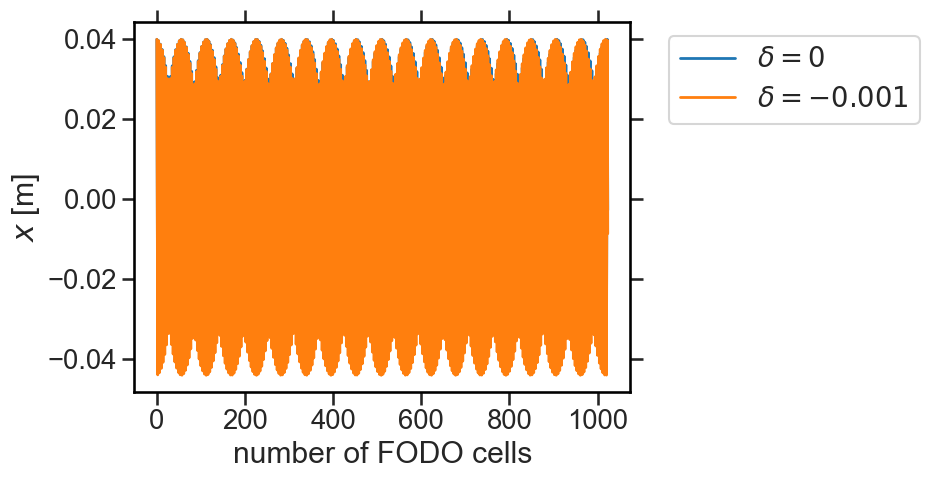

```python
plt.plot(rec_x[:, npart//2 + 1], lw=2, label='$\delta=0$')
plt.plot(rec_x[:, 0], lw=2, label='$\delta=-0.001$')

plt.xlabel('number of FODO cells')
plt.ylabel('$x$ [m]')
plt.legend(bbox_to_anchor=(1.05, 1));
```

```python
# evaluate tunes via NAFF
Qx_delta = np.zeros(npart, dtype=float)

for i in range(npart):
    Qx_delta[i] = PyNAFF.naff(rec_x[:, i], turns=ncells, nterms=1)[0, 1]
```

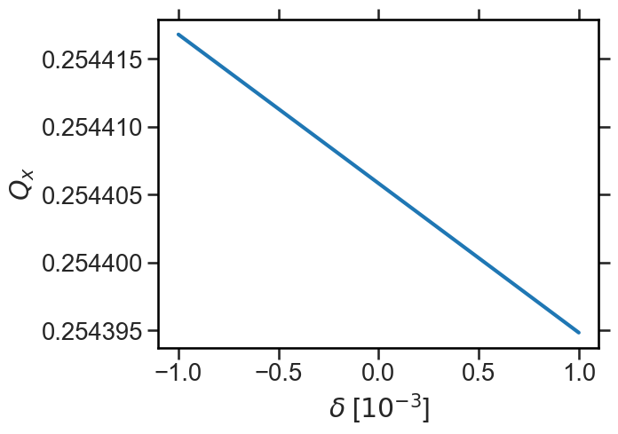

```python
plt.plot(1e3 * delta, Qx_delta)

plt.xlabel('$\delta$ [$10^{-3}$]')
plt.ylabel('$Q_x$');
```

The fit for the now much flatter slope of the tune change with $\delta$ gives:

```python
np.polyfit(delta, Qx_delta, 1)
```

```
array([-0.01098794,  0.25440583])
```

$\implies$ $Q'_x=-0.01$ is nearly zero, i.e. the chromaticity correction scheme works! (The remainders are due to the thin-lens approximation!)

*Hint: we have used 2 sextupoles as 2 degrees of freedom to correct both the horizontal and the vertical chromaticity to zero. One could use only one sextupole degree of freedom, but then only one of the transverse planes can be corrected to $Q'=0$, the other one likely increases!*

## Part II: Synchrotron Radiation

## Synchrotron Radiation

[figure not shown]

Synchrotron light: electromagnetic radiation emitted by charged particles when accelerated in external magnetic field.

$\implies$ Could be from any source (e.g. astrophysical), but is generally thought of as coming from a man-made relativistic beam of electrons.

$\implies$ **Synchrotron radiation sources**:

- high-brightness photon beams
- tunability of photon spectrum
- pulsed time structure

image by [T. Uruga](https://doi.org/10.1007/978-3-319-43866-5_3)

## Emitted power per radiating particle

Moving charged particle source $=$ time-varying charge and current density $\implies$ Maxwell equations and wave equation to find EM fields $\implies$ frequency distribution of radiation and critical frequency $\omega_c$ (median of spectrum)

[figure not shown]

$$\omega_c=\cfrac{3}{2}\cfrac{c}{\rho}\gamma^3$$

$\implies$ Integrating over spectrum yields total radiated power

$$P_\gamma = \cfrac{e^2c}{6\pi\epsilon_0}\cfrac{\gamma^4}{\rho^2}$$

- decreasing bending radius $\rho$ (more bending!) increases critical frequency and power
- mass of particles enters via $\gamma=E_\text{tot}/m_0c^2$ $\implies$ $P_\gamma\propto 1/m_0^4$  
  (electrons radiate **much** more than protons!)

image by I. Martin / Diamond

## Two Types of Sources

Bending magnet (dipole) vs. insertion device (wiggler / undulator):

[figure not shown]

images by [T. Uruga](https://doi.org/10.1007/978-3-319-43866-5_3)

Advantage of insertion devices:

- alternating permanent magnets force electrons onto sinusoidal trajectories
- extremely focused, i.e. ultra-bright photon beams
- wigglers: stronger deflection, broad spectrum
- undulators: weaker deflection, waves interfere constructively, almost mono-chromatic **coherent** synchrotron light

## Synchrotron Radiation Facilities

[figure not shown]

image by [T. Uruga](https://doi.org/10.1007/978-3-319-43866-5_3)

[figure not shown]

Two categories of synchrotron radiation facilities:

1. Storage rings
2. Linac-based sources

$\implies$ Free Electron Lasers:  
photon beam intensity $I\propto N_e^2$ instead of $I\propto N_e$ for conventional sources

## Future Circular lepton Collider FCC-ee

[figure not shown]

images by [CERN](https://home.cern/science/accelerators/future-circular-collider/)

On the high-energy physics front:  
next-generation facility for **high-precision** experiments

$\implies$ Higgs factory to study properties of Higgs  
(discovered at LHC in 2012)

Collide leptons (electrons and positrons) for clean initial state during collision, much smaller background compared to proton colliders $\implies$ precision measurements!

*European Particle Physics Strategy Update* 2026: consider 91 km long FCC-ee proposal as top priority

$\implies$ Key issue of circular high-energy lepton colliders: **synchrotron radiation** (50 MW / beam!)

## Synchrotron Radiation for Beam Size Detectors

[figure not shown]

LHC employs BSRT system: Beam Synchrotron Radiation Telescope

[figure not shown]

images by [F. Caspers](https://indico.cern.ch/event/287930/contributions/660535/attachments/536481/739568/Wendt_LHC_SyncLightMonitor.pdf)

$\implies$ At TeV level, protons do provide enough synchrotron radiation to be "seen"!

## Summary

- Optical / Twiss functions and Dispersion of a FODO cell
- Dipoles generate & quadrupoles focuse dispersion function
- Quadrupole focal length depends on momentum, tune change, chromaticity
- Synchrotron radiation from accelerating/bending charged particles
- Light sources vs. HEP

## TT26 Survey

Thank you very much!

[figure not shown]